# **Problem Statement**

### **Business Context**

The advent of e-news, or electronic news, portals has offered us a great opportunity to quickly get updates on the day-to-day events occurring globally. The information on these portals is retrieved electronically from online databases, processed using a variety of software, and then transmitted to the users. There are multiple advantages of transmitting news electronically, like faster access to the content and the ability to utilize different technologies such as audio, graphics, video, and other interactive elements that are either not being used or aren’t common yet in traditional newspapers.

E-news Express, an online news portal, aims to expand its business by acquiring new subscribers. With every visitor to the website taking certain actions based on their interest, the company plans to analyze these actions to understand user interests and determine how to drive better engagement. The executives at E-news Express believe that there has been a decline in new monthly subscribers compared to the past year because the current webpage is not designed well enough in terms of the outline & recommended content to keep customers engaged long enough to decide to subscribe.

[Companies often analyze user responses to two variants of a product to decide which of the two variants is more effective. This experimental technique, known as A/B testing, is used to determine whether a new feature attracts users based on a chosen metric.]

### **Objectives**

The design team of the company has researched and created a new landing page that has a new outline & more relevant content compared to the old page. To test the effectiveness of the new landing page in gathering new subscribers, the Data Science team experimented by randomly selecting 100 users and dividing them equally into two groups. The existing landing page was served to the first group (control group) and the new landing page to the second group (treatment group). Data regarding the interaction of users in both groups with the two versions of the landing page was collected. Being a data scientist in E-news Express, you have been asked to explore the data and perform a statistical analysis (at a significance level of 5%) to determine the effectiveness of the new landing page in gathering new subscribers for the news portal by answering the following questions:

Do the users spend more time on the new landing page than on the existing landing page? Is the conversion rate (the proportion of users who visit the landing page and get converted) for the new page greater than the conversion rate for the old page? Does the converted status depend on the preferred language? Is the time spent on the new page the same for the different language users?

### **Data Dictionary**

The data contains information regarding the interaction of users in both groups with the two versions of the landing page.

user_id - Unique user ID of the person visiting the website

group - Whether the user belongs to the first group (control) or the second group (treatment)

landing_page - Whether the landing page is new or old

time_spent_on_the_page - Time (in minutes) spent by the user on the landing page

converted - Whether the user gets converted to a subscriber of the news portal or not

language_preferred - language chosen by the user to view the landing page

# **Importing Necessary Libraries and loading data**

```python
# to load and manipulate data
import pandas as pd
import numpy as np

# to visualize data
import matplotlib.pyplot as plt
import seaborn as sns

from scipy.stats import ttest_ind
from statsmodels.stats.proportion import proportions_ztest
from scipy.stats import chi2_contingency
from scipy import stats
from scipy.stats import levene
from scipy.stats import f_oneway
```

```python
from google.colab import drive
drive.mount('/content/drive')
```

```python
abtest_model = pd.read_csv("/content/drive/MyDrive/abtest.csv")
data = abtest_model.copy()
```

# **Data Overview and Preprocessing**

```python
data.head(5)
```

|  | user_id | group | landing_page | time_spent_on_the_page | converted | language_preferred |
| --- | --- | --- | --- | --- | --- | --- |
| 0 | 546592 | control | old | 3.48 | no | Spanish |
| 1 | 546468 | treatment | new | 7.13 | yes | English |
| 2 | 546462 | treatment | new | 4.40 | no | Spanish |
| 3 | 546567 | control | old | 3.02 | no | French |
| 4 | 546459 | treatment | new | 4.75 | yes | Spanish |

```python
data.tail(5)
```

|  | user_id | group | landing_page | time_spent_on_the_page | converted | language_preferred |
| --- | --- | --- | --- | --- | --- | --- |
| 95 | 546446 | treatment | new | 5.15 | no | Spanish |
| 96 | 546544 | control | old | 6.52 | yes | English |
| 97 | 546472 | treatment | new | 7.07 | yes | Spanish |
| 98 | 546481 | treatment | new | 6.20 | yes | Spanish |
| 99 | 546483 | treatment | new | 5.86 | yes | English |

```python
data.shape
```

```
(100, 6)
```

The dataset has 100 rows and 6 columns.

```python
data.info()
```

```
<class 'pandas.core.frame.DataFrame'>
RangeIndex: 100 entries, 0 to 99
Data columns (total 6 columns):
 #   Column                  Non-Null Count  Dtype
---  ------                  --------------  -----
 0   user_id                 100 non-null    int64
 1   group                   100 non-null    object
 2   landing_page            100 non-null    object
 3   time_spent_on_the_page  100 non-null    float64
 4   converted               100 non-null    object
 5   language_preferred      100 non-null    object
dtypes: float64(1), int64(1), object(4)
memory usage: 4.8+ KB
```

There are 2 numeric columns and 4 categorical columns.

No missing values found.

User_id is unique identifier for each row.

```python
data.nunique()
```

|  | 0 |
| --- | --- |
| user_id | 100 |
| group | 2 |
| landing_page | 2 |
| time_spent_on_the_page | 94 |
| converted | 2 |
| language_preferred | 3 |

**dtype:** int64

```python
data.describe().T
```

|  | count | mean | std | min | 25% | 50% | 75% | max |
| --- | --- | --- | --- | --- | --- | --- | --- | --- |
| user_id | 100.0 | 546517.0000 | 52.295779 | 546443.00 | 546467.75 | 546492.500 | 546567.2500 | 546592.00 |
| time_spent_on_the_page | 100.0 | 5.3778 | 2.378166 | 0.19 | 3.88 | 5.415 | 7.0225 | 10.71 |

Minimum time spent on the page is less than a minute and maximum time spent is a little over 10 minutes. On average, a user spends around 5 minutes on the page.

```python
data["group"].value_counts()
```

| group | count |
| --- | --- |
| control | 50 |
| treatment | 50 |

**dtype:** int64

The data is balanced. Out of 100, 50 users belong to the first group (control) and the other 50 belong to the second group (treatment).

```python
data["landing_page"].value_counts()
```

| landing_page | count |
| --- | --- |
| old | 50 |
| new | 50 |

**dtype:** int64

```python
data[data['landing_page']=='old']['group'].value_counts()
```

| group | count |
| --- | --- |
| control | 50 |

**dtype:** int64

```python
data[data['landing_page']=='new']['group'].value_counts()
```

| group | count |
| --- | --- |
| treatment | 50 |

**dtype:** int64

The data is balanced. The old landing page was served to the first group (control group) and the new landing page to the second group (treatment group).

```python
data[data['converted']=='yes']['landing_page'].value_counts()
```

| landing_page | count |
| --- | --- |
| new | 33 |
| old | 21 |

**dtype:** int64

Among the users who got converted to subscriber, 33 of them used new landing page and 21 used old.

```python
data[data['converted']=='no']['landing_page'].value_counts()
```

| landing_page | count |
| --- | --- |
| old | 29 |
| new | 17 |

**dtype:** int64

From this dataset, it is clearly seen that users trying the new landing page has more chance of converting than the ones using the old page,

```python
data[data['language_preferred']=='English']['converted'].value_counts()
```

| converted | count |
| --- | --- |
| yes | 21 |
| no | 11 |

**dtype:** int64

Among users who prefer English, a higher number have converted to subscribers compared to those who did not convert.

```python
data[data['language_preferred']=='French']['converted'].value_counts()
```

| converted | count |
| --- | --- |
| no | 19 |
| yes | 15 |

**dtype:** int64

For French users, 44.12% converted to subscribers, while 55.88% did not convert.

```python
data[data['language_preferred']=='Spanish']['converted'].value_counts()
```

| converted | count |
| --- | --- |
| yes | 18 |
| no | 16 |

**dtype:** int64

Spanish users also have high conversion to subscribers but at a lesser rate than English.

```python
data[data['converted']=='yes']['language_preferred'].value_counts()
```

| language_preferred | count |
| --- | --- |
| English | 21 |
| Spanish | 18 |
| French | 15 |

**dtype:** int64

Users who prefer English as their language are more likely to convert into subscribers compared to other languages

```python
# checking for null values
data.isnull().sum()
```

|  | 0 |
| --- | --- |
| user_id | 0 |
| group | 0 |
| landing_page | 0 |
| time_spent_on_the_page | 0 |
| converted | 0 |
| language_preferred | 0 |

**dtype:** int64

There are no missing values.

```python
data.duplicated().sum()
```

```
np.int64(0)
```

There are no duplicate values.

## **Univariate Analysis**

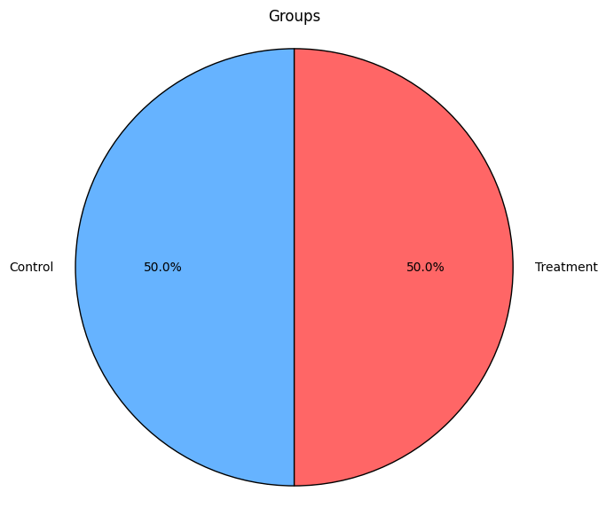

```python
# Plotting the pie chart
plt.figure(figsize=(7, 7))
plt.pie(data['group'].value_counts(), labels=['Control','Treatment'], autopct='%1.1f%%', colors=['#66b3ff', '#ff6666'], startangle=90, wedgeprops={'edgecolor': 'black'})
plt.title('Groups')
plt.axis('equal')
plt.show()
```

In the sample provided, there is equal number of people in the 2 groups.

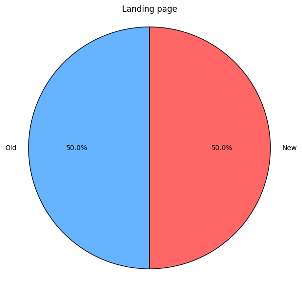

```python
# Plotting the pie chart
plt.figure(figsize=(7, 7))
plt.pie(data['landing_page'].value_counts(), labels=['Old','New'], autopct='%1.1f%%', colors=['#66b3ff', '#ff6666'], startangle=90, wedgeprops={'edgecolor': 'black'})
plt.title('Landing page')
plt.axis('equal')
plt.show()
```

In the sample provided, there is equal number of users who tried old and new landing pages.

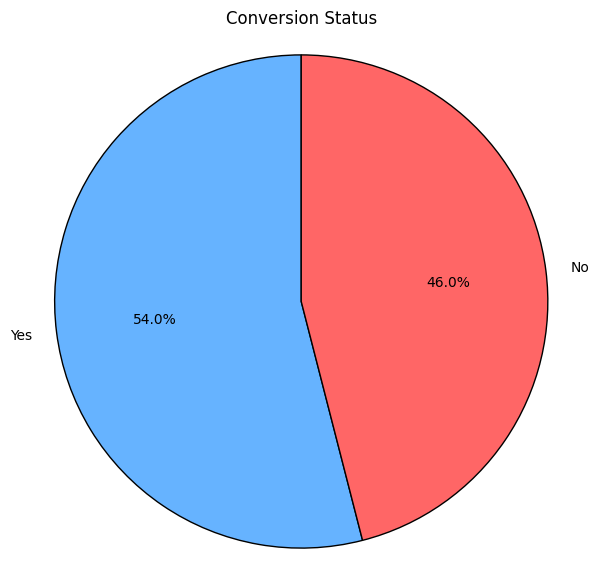

```python
# Plotting the pie chart
plt.figure(figsize=(7, 7))
plt.pie(data['converted'].value_counts(), labels=['Yes','No'], autopct='%1.1f%%', colors=['#66b3ff', '#ff6666'], startangle=90, wedgeprops={'edgecolor': 'black'})
plt.title('Conversion Status')
plt.axis('equal')
plt.show()
```

More than half of the users converted to subscribers.

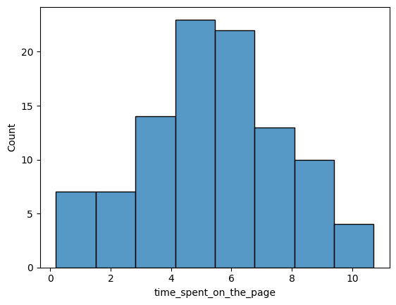

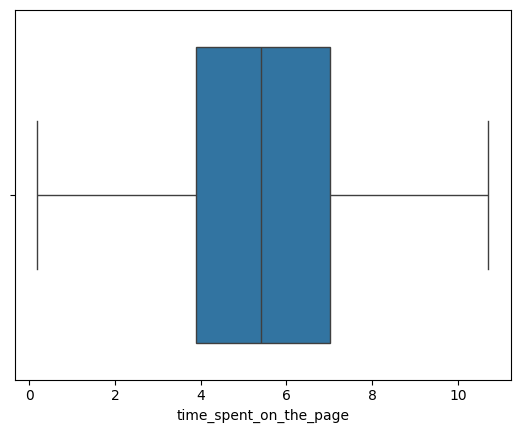

```python
sns.histplot(data=data, x='time_spent_on_the_page')
plt.show()
sns.boxplot(data=data, x='time_spent_on_the_page')
plt.show()
```

It is close to a normal distribution with average time spent on the page around 5 minutes.

```
language_preferred
Spanish    34.0
French     34.0
English    32.0
Name: proportion, dtype: float64
```

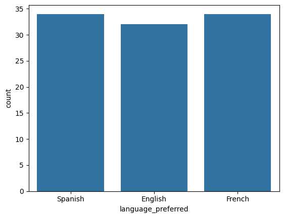

```python
print(100*data['language_preferred'].value_counts(normalize=True), '\n')
sns.countplot(data=data, x='language_preferred')
plt.show()
```

There are more number of Spanish and French users when compared to English.

## **Bivariate and Multivariate Analysis**

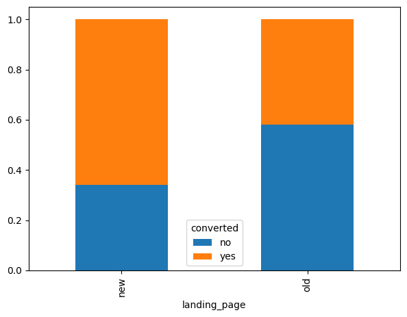

```python
tab = pd.crosstab(
    data['landing_page'],
    data['converted'],
    normalize='index'
)
tab.plot(kind='bar', stacked=True, figsize=(7, 5))
```

There is more conversion rate among the users using the new landing page when compared to the old landing page.

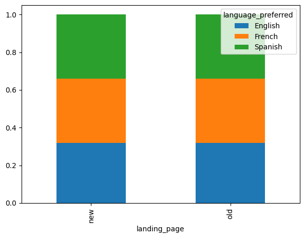

```python
tab = pd.crosstab(
    data['landing_page'],
    data['language_preferred'],
    normalize='index'
)
tab.plot(kind='bar', stacked=True, figsize=(7, 5))
```

Among users on both the old and new landing pages, there is no significant difference in the ratio of English, French, and Spanish users.

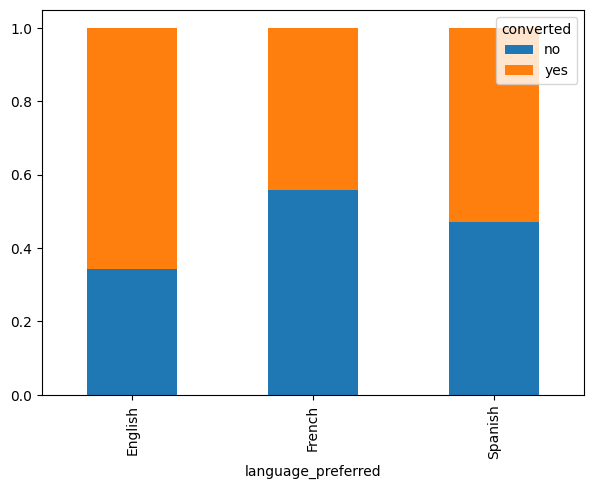

```python
tab = pd.crosstab(
    data['language_preferred'],
    data['converted'],
    normalize='index'
)
tab.plot(kind='bar', stacked=True, figsize=(7, 5))
```

More conversion rate is observed in English users followed by Spanish users.

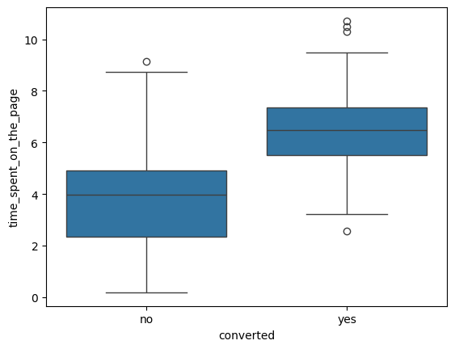

```python
sns.boxplot(data=data, x='converted', y='time_spent_on_the_page');
plt.show()
```

Users who did not convert have a median around 4 minutes.

Users who converted have a higher median around 6.5 minutes.

This suggests people who spent more time on the page were more likely to convert.

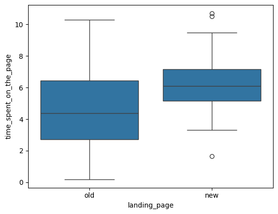

```python
sns.boxplot(data=data, x='landing_page', y='time_spent_on_the_page');
plt.show()
```

Old page has a wider spread, IQR roughly 3 to 6.5 minutes.

New page has a narrower spread, IQR roughly 5 to 7 minutes.

Time spent is more consistent on the new page, while the old page shows more variation.

Users spent more time on the new landing page than the old one.

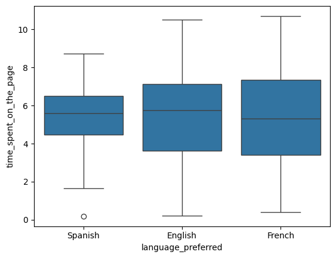

```python
sns.boxplot(data=data, x='language_preferred', y='time_spent_on_the_page');
plt.show()
```

```python
data.groupby("language_preferred")["time_spent_on_the_page"].describe()
```

| language_preferred | count | mean | std | min | 25% | 50% | 75% | max |
| --- | --- | --- | --- | --- | --- | --- | --- | --- |
| English | 32.0 | 5.559062 | 2.621079 | 0.22 | 3.6175 | 5.755 | 7.1375 | 10.50 |
| French | 34.0 | 5.253235 | 2.675413 | 0.40 | 3.3950 | 5.315 | 7.3675 | 10.71 |
| Spanish | 34.0 | 5.331765 | 1.818095 | 0.19 | 4.4750 | 5.605 | 6.5150 | 8.72 |

English users spent slightly more time on average, while French has the lowest mean.

Spanish users are more consistent in their time spent, while English & French users show wider spread (some spending very little, some a lot).

## **Insights**

- New landing page drives higher engagement

Users spent more time and showed more consistent engagement on the new landing page compared to the old one.

The new design is likely more attractive and user-friendly, reducing drop-offs.

Investing in the new design could improve conversion efficiency.

- Strong link between time spent and conversion

Users who spent longer time on the page were more likely to convert.

Engagement time acts as a leading indicator of conversion.

- Adding engaging content (videos, testimonials, interactive FAQs) could further increase dwell time and boost conversions.

Language distribution is balanced across pages

The ratio of English, French, and Spanish users is similar across old and new pages, indicating no design bias toward a particular language group.

The landing page experience is equally accessible to all language segments.

No localization issues, but tailored micro-content for each language could unlock more conversions.

- User behavior differs by language

Spanish users may prefer direct/concise experiences, while English & French users engage with richer content.

Personalize content style by language (concise flow for Spanish, detailed narratives for English/French).

- Conversion rate varies by language

English users have the highest conversion rates, followed by Spanish, then French.

Targeted campaigns for French users could help close the gap; leveraging English strengths could maximize ROI.

- Engagement consistency differs by page type

New page → more consistent engagement.

Old page → higher variability (some spend very little time, others much more).

The new design appeals more evenly across users, reducing extreme drop-offs.

Standardized experiences reduce risk and improve predictability of conversions.

# **Question 1**

Do the users spend more time on the new landing page than the old landing page?

**Hypothesis**

Null Hypothesis (H₀): The time spent on the new page is the same as the time spent on the old page.

Alternative Hypothesis (H₁): The time spent on the new landing page is greater than the old page.

```python
data[['landing_page','time_spent_on_the_page']].head(10)
```

|  | landing_page | time_spent_on_the_page |
| --- | --- | --- |
| 0 | old | 3.48 |
| 1 | new | 7.13 |
| 2 | new | 4.40 |
| 3 | old | 3.02 |
| 4 | new | 4.75 |
| 5 | old | 5.28 |
| 6 | new | 5.25 |
| 7 | old | 6.53 |
| 8 | new | 10.71 |
| 9 | old | 2.08 |

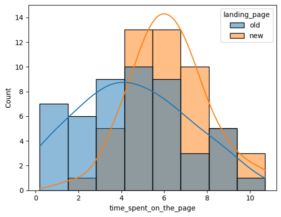

```python
sns.histplot(data=data, x='time_spent_on_the_page', hue='landing_page', kde=True)
```

The old landing page (blue) shows a flatter, wider spread.

The new landing page (orange) looks more bell-shaped, closer to normal.

```python
old_mean=data[data['landing_page']=='old']['time_spent_on_the_page'].mean()
new_mean=data[data['landing_page']=='new']['time_spent_on_the_page'].mean()
old_std=data[data['landing_page']=='old']['time_spent_on_the_page'].std()
new_std=data[data['landing_page']=='new']['time_spent_on_the_page'].std()
```

```python
# find the sample means and sample standard deviations for the two samples
print('The mean time spent on old landing page is ' + str(round(old_mean,2))+' minutes')
print('The mean time spent on new landing page is ' + str(round(new_mean,2))+' minutes')
print('The standard deviation of time spent on old landing page is ' + str(round(old_std, 2))+' minutes')
print('The standard deviation of time spent on new landing page is ' + str(round(new_std, 2))+' minutes')
```

```
The mean time spent on old landing page is 4.53 minutes
The mean time spent on new landing page is 6.22 minutes
The standard deviation of time spent on old landing page is 2.58 minutes
The standard deviation of time spent on new landing page is 1.82 minutes
```

Since time_spent is a continuous variable and we are comparing two samples where the population standard deviation is unknown, **two sample T-test** is the appropriate test.

Validating the assumptions:

Continuous data - Yes, the time spent on the page is measured on a continuous scale.

Normally distributed populations - As visualised above, neither distribution is perfectly normal, but for sample sizes of ~50 per group, the Central Limit Theorem kicks in — meaning the sampling distribution of the mean is approximately normal.

Independent populations - Yes, 100 users were randomly selected and divided equally into two groups.

Unequal population standard deviations - As the sample standard deviations are different, the population standard deviations may be assumed to be different.

Random sampling from the population - Yes, we are informed that the collected sample a simple random sample.

Hence, we can use two sample T-test for this problem.

```python
# find the p-value
test_stat, p_value = ttest_ind(data[data['landing_page']=='new']['time_spent_on_the_page'], data[data['landing_page']=='old']['time_spent_on_the_page'], equal_var = False, alternative = 'greater')
print('The p-value is ', p_value)
```

```
The p-value is  0.0001392381225166549
```

# **Question 2**

Is the conversion rate (the proportion of users who visit the landing page and get converted) for the new page greater than the conversion rate for the old page?

**Hypothesis**

Null Hypothesis (H₀): The conversion rate for the new page is equal to the conversion rate for the old page.

Alternative Hypothesis (H₁): The conversion rate for the new page is greater than the conversion rate for the old page.

```python
data[['landing_page','converted']].head(10)
```

|  | landing_page | converted |
| --- | --- | --- |
| 0 | old | no |
| 1 | new | yes |
| 2 | new | no |
| 3 | old | no |
| 4 | new | yes |
| 5 | old | yes |
| 6 | new | yes |
| 7 | old | yes |
| 8 | new | yes |
| 9 | old | no |

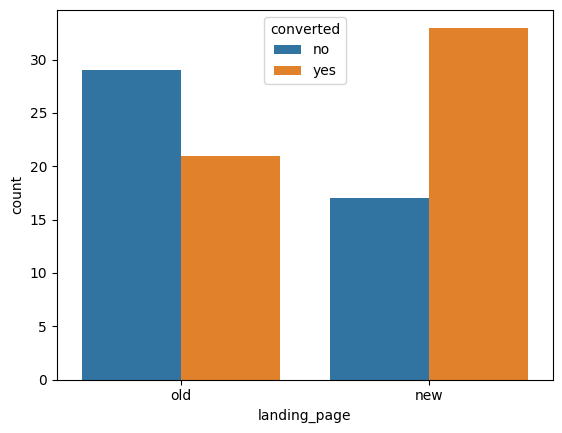

```python
sns.countplot(data=data, x='landing_page', hue='converted')
```

Conversion rate is visibly low among users using old landing page.

There is significantly more users getting converted to subscribers while using new landing page.

```python
data.groupby("landing_page")["converted"].value_counts()
```

| landing_page | converted | count |
| --- | --- | --- |
| new | yes | 33 |
|  | no | 17 |
| old | no | 29 |
|  | yes | 21 |

**dtype:** int64

## Inference

Since conversion status is Categorical (converted: yes/no), comparing two proportions (conversion rates), **Two-proportion Z Test** is the appropriate test.

### Two Proportion Z-test assumptions

Binomally distributed population - Yes, a user is either converted or not converted.

Random sampling from the population - Yes, we are informed that the collected sample is a simple random sample.

Can the binomial distribution approximated to normal distribution - Yes. For binary data, CLT works slower than usual. The standard thing is to check whether np and n(1-p) are greater than or equal to 10. Here, n and p refer to the sample size and sample proportion respectively.

> $np_1 = 50\cdot \frac{33}{50} =33 \geq 10\\ n(1-p_1) = 50 \cdot \frac{17}{50} =17 \geq 10 \\ np_2 = 50\cdot \frac{21}{50} =21 \geq 10\\ n(1-p_2) = 50 \cdot \frac{29}{50} =29 \geq 10 $

```python
# set the counts of converted users
defect_count = np.array([33, 21])

# set the sample sizes
nobs = np.array([50, 50])

# find the p-value
test_stat, p_value = proportions_ztest(defect_count, nobs)
print('The p-value is ' + str(p_value))
```

```
The p-value is 0.016052616408112556
```

As the p-value (~0.016) is less than the level of significance (0.05), we can reject the null hypothesis. Hence, we have enough evidence that the **conversion rate for the new page is greater than the conversion rate for the old page**.

# **Question 3**

Does the converted status depend on the preferred language?

**Hypothesis**

Null Hypothesis (H₀): Conversion status is independent of preferred language.

Alternative Hypothesis (H₁): Conversion status depends on preferred language.

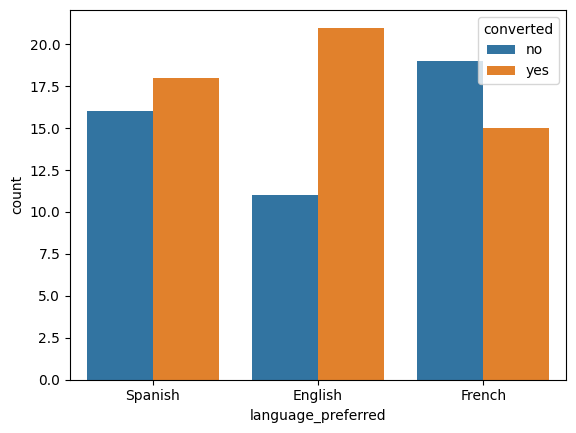

```python
sns.countplot(data=data,x='language_preferred',hue='converted')
```

English users have more number of conversions compared to Spanish or French users.

Since we need to associate between two categorical variables (conversion: yes/no, language: English/French/Spanish), **Chi-Square Test of Independence** is the appropriate test.

### Chi-Square Test of Independence Assumptions

- Categorical variables - Yes
- Expected value of the number of sample observations in each level of the variable is at least 5 - Yes, the number of observations in each level is greater than 5.
- Random sampling from the population - Yes, we are informed that the collected sample is a simple random sample.

```python
#contingency table
contingency = pd.crosstab(data['language_preferred'], data['converted'])
contingency
```

| converted language_preferred | no | yes |
| --- | --- | --- |
| English | 11 | 21 |
| French | 19 | 15 |
| Spanish | 16 | 18 |

```python
# find the p-value
chi, p_value, dof, expected = chi2_contingency(contingency)
print('The p-value is', p_value)
```

```
The p-value is 0.2129888748754345
```

## Inference

As the p-value (~0.213) is greater than the level of significance (0.05), we can not reject the null hypothesis. Hence, we conclude that **converted status is independent of preferred language**. There is no statistically significant association between the two variables.

# **Question 4**

Is the time spent on the new page the same for the different language users?

**Hypothesis**

Null Hypothesis (H₀): The mean time spent on the new page is the same across all language groups.

Alternative Hypothesis (H₁): At least one language group has a different mean time spent on the new page.

```python
#since we are analysing the new landing page, setting it as new variable
new_landing_page = data[data['landing_page']=='new']
new_landing_page.head()
```

|  | user_id | group | landing_page | time_spent_on_the_page | converted | language_preferred |
| --- | --- | --- | --- | --- | --- | --- |
| 1 | 546468 | treatment | new | 7.13 | yes | English |
| 2 | 546462 | treatment | new | 4.40 | no | Spanish |
| 4 | 546459 | treatment | new | 4.75 | yes | Spanish |
| 6 | 546448 | treatment | new | 5.25 | yes | French |
| 8 | 546461 | treatment | new | 10.71 | yes | French |

```python
#filter the data for the new landing page and group by preferred language to display time spent statistics
new_landing_page.groupby('language_preferred')['time_spent_on_the_page'].describe()
```

| language_preferred | count | mean | std | min | 25% | 50% | 75% | max |
| --- | --- | --- | --- | --- | --- | --- | --- | --- |
| English | 16.0 | 6.663750 | 1.984150 | 3.65 | 5.3275 | 6.865 | 7.7125 | 10.50 |
| French | 17.0 | 6.196471 | 1.933394 | 3.30 | 5.2500 | 5.420 | 7.2700 | 10.71 |
| Spanish | 17.0 | 5.835294 | 1.525656 | 1.65 | 5.1500 | 6.200 | 6.7000 | 8.08 |

Time spent on the page is the response variable and the language preferred is the factor.

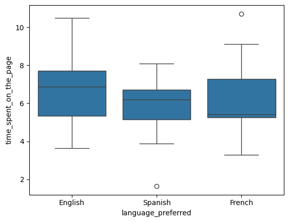

```python
sns.boxplot(data=new_landing_page, x='language_preferred', y='time_spent_on_the_page');
```

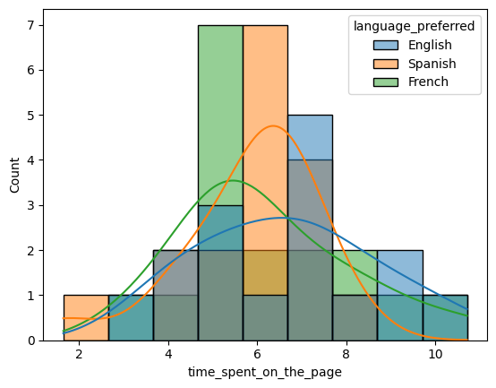

```python
sns.histplot(data=new_landing_page, x='time_spent_on_the_page', hue='language_preferred', kde=True)
```

**One-way Anova test** will be the appropriate test to correlate Continuous variable (time spent), grouped by 3 categories (languages- English, Spanish, French)

To test: normality and equality of variance assumptions.

For testing of normality, Shapiro-Wilk’s test is applied to the response variable.

For equality of variance, Levene test is applied to the response variable.

## Shapiro-Wilk's Test

For testing of normality, Shapiro-Wilk’s test is applied to the response variable.

Null Hypothesis H₀: Time spent on the page follows a normal distribution

Alternative hypothesis H₁: Time spent on the page does not follow a normal distribution

```python
w, p_value = stats.shapiro(new_landing_page['time_spent_on_the_page'])
print('The p-value is', p_value)
```

```
The p-value is 0.8040040364746845
```

Since p-value is very large, we fail to reject the null hypothesis. Hence, we can conclude the response follows normal distribution.

## Levene's Test

For equality of variance, Levene test is applied to the response variable.

Null Hypothesis H₀: All the population variances are equal.

Alternative hypothesis H₁: Atleast one variance is different from the rest.

```python
statistic, p_value = levene( new_landing_page['time_spent_on_the_page'][new_landing_page['language_preferred']=="English"], new_landing_page['time_spent_on_the_page'][new_landing_page['language_preferred']=="Spanish"], new_landing_page['time_spent_on_the_page'][new_landing_page['language_preferred']=="French"])
# find the p-value
print('The p-value is', p_value)
```

```
The p-value is 0.46711357711340173
```

Since the p-value is large, we fail to reject the null hypothesis of homogeneity of variances.

## Assumptions for One-way Anova Test

The populations are normally distributed - Yes, the normality assumption is verified using the Shapiro-Wilk’s test. Samples are independent simple random samples - Yes, we are informed that the collected sample is a simple random sample. Population variances are equal - Yes, the homogeneity of variance assumption is verified using the Levene's test.

```python
# perform one-way anova test
test_stat, p_value = f_oneway(new_landing_page.loc[new_landing_page['language_preferred'] == 'English', 'time_spent_on_the_page'], new_landing_page.loc[new_landing_page['language_preferred'] == 'Spanish', 'time_spent_on_the_page'], new_landing_page.loc[new_landing_page['language_preferred'] == 'French', 'time_spent_on_the_page'])
print('The p-value is ' + str(p_value))
```

```
The p-value is 0.43204138694325955
```

## Inference

As the p-value is significantly large (~0.43) compared to the level of significance (0.05), we can not reject the null hypothesis. Hence, we can conclude **the time spent on the new page is the same for the different language users**.

# **Conclusion**

The A/B testing analysis strongly suggests that the new landing page outperforms the old page in both user engagement and conversion effectiveness:

- Users spend significantly more time on the new landing page, indicating higher engagement levels.
- The conversion rate (proportion of users subscribing) is also significantly higher for the new landing page compared to the old one.
- The preferred language does not influence whether a user converts — subscription decisions are independent of language.
- Among users of the new landing page, the time spent does not differ significantly by language, meaning the new design works equally well across English, French, and Spanish users.

Together, these findings provide strong evidence that the new landing page is more effective at driving both engagement and subscriptions, regardless of language preferences.

# **Business Recommendations**

Based on the above insights, E-News Express should:

- Adopt the New Landing Page Roll out the new landing page to all users since it drives both higher engagement and conversion.
- Leverage Engagement to Boost Conversions Since time spent correlates with conversion, add more engaging content and interactive features to keep users on the page longer.
- Personalization Not Critical by Language As language does not impact conversion or time spent significantly, there’s no immediate need to create different landing page versions by language. Resources can instead focus on content quality and design.
- Monitor & Optimize Continuously Track engagement and conversion rates periodically, especially as new content formats are introduced.